# Análisis de la Esperanza de Vida en Diferentes Regiones del Mundo

##### Tabla de frecuencia

```r
print(generar_tabla_frecuencias(df, "Education Expenditure %"))
```

```
##     Intervalo Frecuencia.Absoluta Frecuencia.Relativa.... Frecuencia.Acumulada
## 1 2.00 - 2.50                   1               0.5747126                    1
## 2 2.50 - 3.00                  15               8.6206897                   16
## 3 3.00 - 3.50                  13               7.4712644                   29
## 4 3.50 - 4.00                  12               6.8965517                   41
## 5 4.00 - 4.50                 111              63.7931034                  152
## 6 4.50 - 5.00                  10               5.7471264                  162
## 7 5.00 - 5.50                   6               3.4482759                  168
## 8 5.50 - 6.00                   6               3.4482759                  174
##   Frecuencia.Relativa.Acumulada....
## 1                         0.5747126
## 2                         9.1954023
## 3                        16.6666667
## 4                        23.5632184
## 5                        87.3563218
## 6                        93.1034483
## 7                        96.5517241
## 8                       100.0000000
```

##### Histograma:

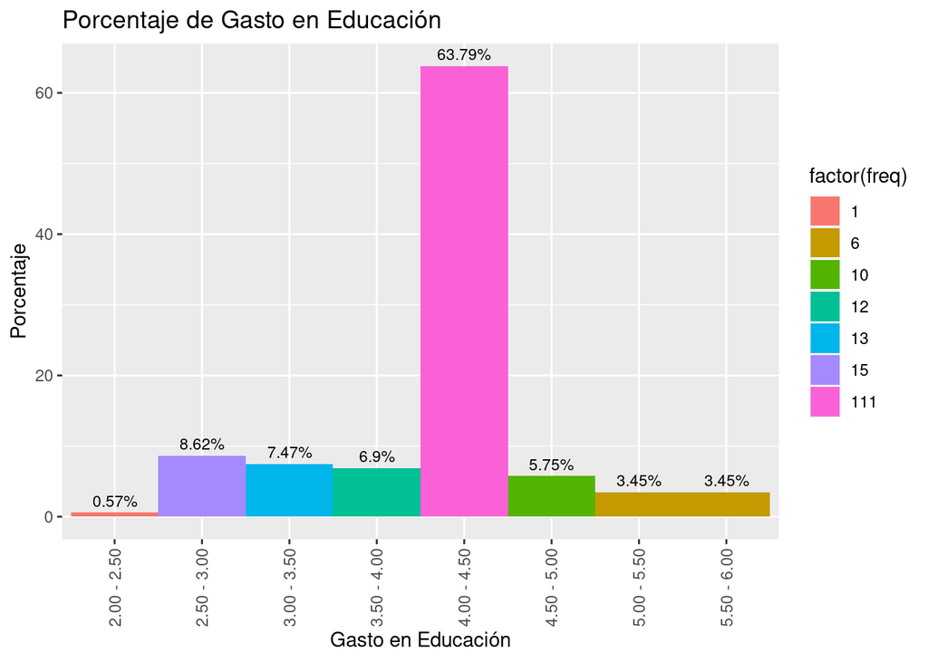

```r
generar_histograma(df, "Education Expenditure %", "Gasto en Educación", "Porcentaje de Gasto en Educación")
```

#### Desempleo (% de la población activa total)

La tasa de desempleo es un indicador clave para evaluar la situación económica de un país. En la base de datos original, esta variable tiene una media de 6.883121, una mediana de 5.6065 y una desviación estándar de 5.274997. Tras la limpieza de la base de datos, la media disminuye a 5.613848, la mediana disminuye ligeramente a 5.59825, y la desviación estándar disminuye significativamente a 3.097995. Esto indica que, en promedio, la tasa de desempleo es cercana al 5.61%, con una tendencia hacia el 5.60%. La disminución de la desviación estándar sugiere una mayor homogeneidad en los datos.

##### Base de datos original:

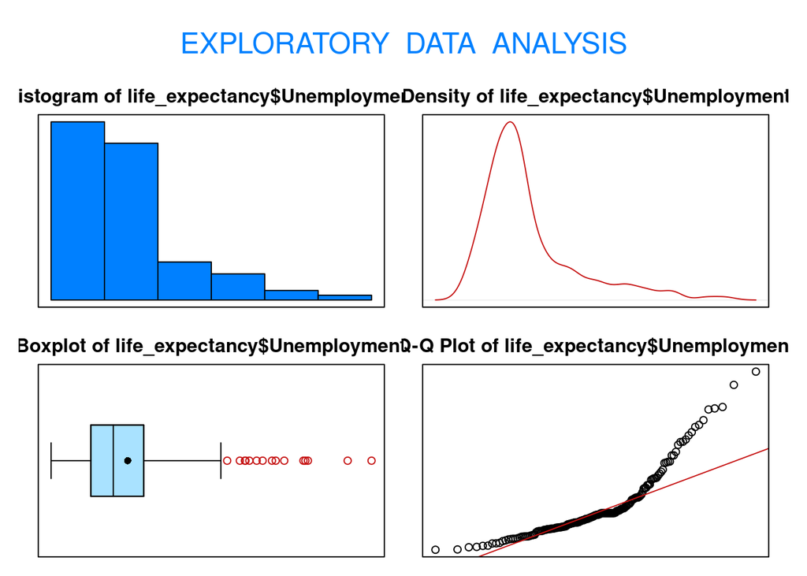

```
## Size (n)  Missing  Minimum   1st Qu     Mean   Median   TrMean   3rd Qu
##  174.000    0.000    0.100    3.620    6.883    5.607    6.390    8.273
##      Max    Stdev      Var  SE Mean   I.Q.R.    Range Kurtosis Skewness
##   28.470    5.275   27.826    0.400    4.653   28.370    2.810    1.679
## SW p-val
##    0.000
```

```r
eda(life_expectancy$Unemployment)
```

##### Base de datos limpia:

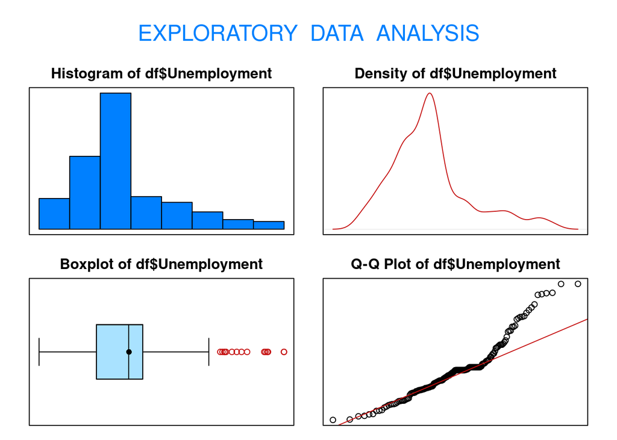

```
## Size (n)  Missing  Minimum   1st Qu     Mean   Median   TrMean   3rd Qu
##  174.000    0.000    0.100    3.620    5.614    5.598    5.443    6.435
##      Max    Stdev      Var  SE Mean   I.Q.R.    Range Kurtosis Skewness
##   15.130    3.098    9.598    0.235    2.815   15.030    0.950    0.971
## SW p-val
##    0.000
```

```r
eda(df$Unemployment)
```

##### Tabla de frecuencia

```r
print(generar_tabla_frecuencias(df, "Unemployment"))
```

```
##       Intervalo Frecuencia.Absoluta Frecuencia.Relativa....
## 1  0.00 -  2.00                  16                9.195402
## 2  2.00 -  4.00                  38               21.839080
## 3  4.00 -  6.00                  71               40.804598
## 4  6.00 -  8.00                  17                9.770115
## 5  8.00 - 10.00                  14                8.045977
## 6 10.00 - 12.00                   9                5.172414
## 7 12.00 - 14.00                   5                2.873563
## 8 14.00 - 16.00                   4                2.298851
##   Frecuencia.Acumulada Frecuencia.Relativa.Acumulada....
## 1                   16                          9.195402
## 2                   54                         31.034483
## 3                  125                         71.839080
## 4                  142                         81.609195
## 5                  156                         89.655172
## 6                  165                         94.827586
## 7                  170                         97.701149
## 8                  174                        100.000000
```

##### Histograma:

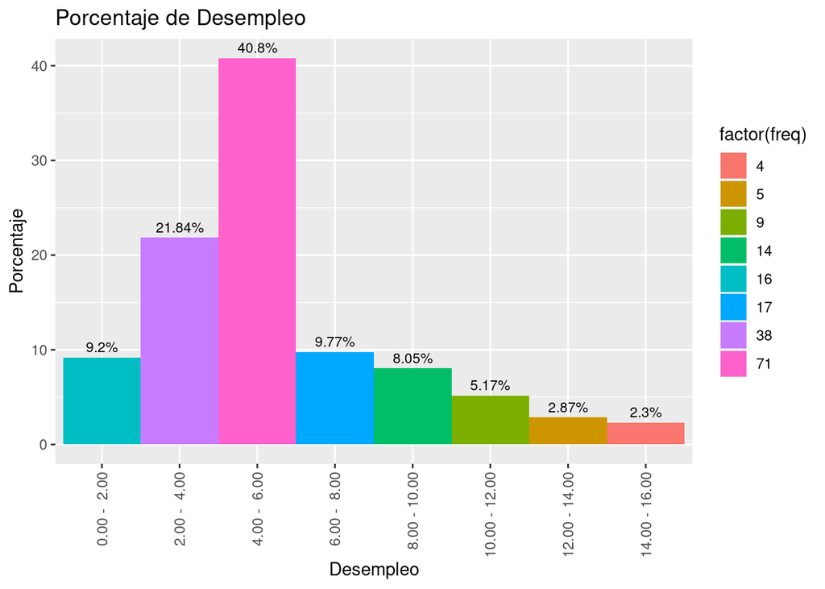

```r
generar_histograma(df, "Unemployment", "Desempleo", "Porcentaje de Desempleo")
```